# HW 2

Author

Caitlin Worline

## Set Up

```r
# Call data library
library(nycflights13)
library(dplyr)
library(ggplot2)

# Load data into Environment
airlines <- airlines
airports <- airports
flights  <- flights
planes   <- planes
weather  <- weather
```

## Question 1

Find the top 10 most popular destinations in the flights data. How many flights went to each?

```r
# Top 10 most popular destinations
library(dplyr)

flights %>%
  count(dest) %>%
  top_n(10, n) %>%
  arrange(desc(n))
```

```
# A tibble: 10 × 2
   dest      n
   <chr> <int>
 1 ORD   17283
 2 ATL   17215
 3 LAX   16174
 4 BOS   15508
 5 MCO   14082
 6 CLT   14064
 7 SFO   13331
 8 FLL   12055
 9 MIA   11728
10 DCA    9705
```

## Question 2

Create two new categorical variables in flights based on the departure time (dep_time), and arrival time (arr_time). These new variables should have four categories: “early morning” for 12am to 6am, “morning” for 6am to 12pm, “afternoon” for 12pm to 6pm, and “evening” for 6pm to 12am. Show barplots of both of these new variables. What percentage of flights were “red eye” flights? We’ll define these as flights that depart in “afternoon” or “evening” and arrive in “early morning” or “morning.”

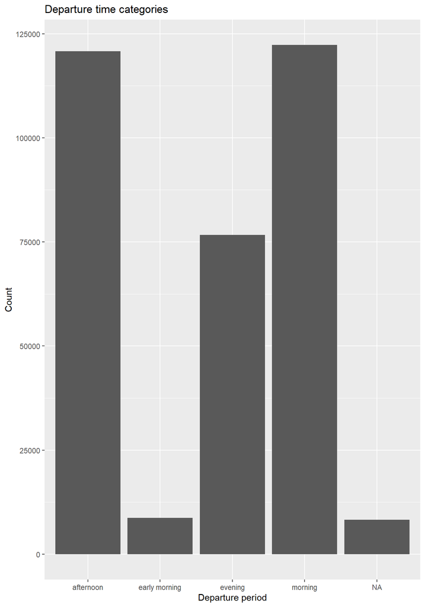

```r
# Departure/arrival time categories
flights_timecat <- flights %>%
  mutate(
    dep_hour = floor(dep_time / 100),
    arr_hour = floor(arr_time / 100),
    dep_period = case_when(
      dep_hour >= 0  & dep_hour < 6  ~ "early morning",
      dep_hour >= 6  & dep_hour < 12 ~ "morning",
      dep_hour >= 12 & dep_hour < 18 ~ "afternoon",
      dep_hour >= 18 & dep_hour < 24 ~ "evening",
      TRUE ~ NA_character_
    ),
    arr_period = case_when(
      arr_hour >= 0  & arr_hour < 6  ~ "early morning",
      arr_hour >= 6  & arr_hour < 12 ~ "morning",
      arr_hour >= 12 & arr_hour < 18 ~ "afternoon",
      arr_hour >= 18 & arr_hour < 24 ~ "evening",
      TRUE ~ NA_character_
    )
  )

# Barplot for both categories
ggplot(flights_timecat, aes(x = dep_period)) +
  geom_bar() +
  labs(title = "Departure time categories", x = "Departure period", y = "Count")
```

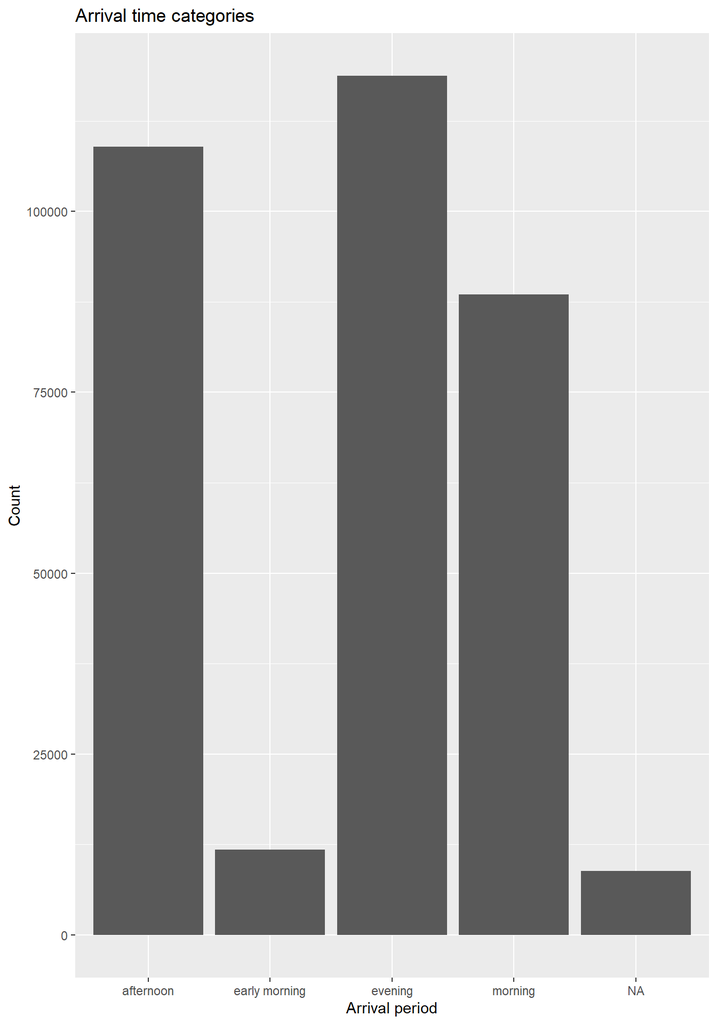

```r
ggplot(flights_timecat, aes(x = arr_period)) +
  geom_bar() +
  labs(title = "Arrival time categories", x = "Arrival period", y = "Count")
```

```r
# Red-eye flights percentages
flights_redeye <- flights_timecat %>%
  mutate(
    redeye = dep_period %in% c("afternoon", "evening") &
             arr_period %in% c("early morning", "morning")
  )

redeye_pct <- flights_redeye %>%    # 3.15% are redeye flights
  summarise(
    pct_redeye = mean(redeye, na.rm = TRUE) * 100
  )
```

## Question 3

Were there any planes that flew for multiple airlines? If so, how many were there and which airlines did they fly for?

# Summary

```
- In the flights dataset, I found that 17 planes that flew for more than one airline, and each of these aircraft appeared under exactly two different carriers, resulting in 34 plane–airline combinations.
```

```r
# Find planes that appear with more than one carrier
library(dplyr)

planes_multi <- flights %>%
  filter(!is.na(tailnum), !is.na(carrier)) %>%
  distinct(tailnum, carrier) %>%   # unique plane–airline pairs
  count(tailnum) %>%               # count how many airlines per plane
  filter(n > 1)                    # keep only planes with >1 airline

# Which airlines did each of those planes fly for?
planes_multi_detail <- flights %>%
  filter(tailnum %in% planes_multi$tailnum) %>%
  distinct(tailnum, carrier) %>%
  arrange(tailnum)

planes_multi_detail
```

```
# A tibble: 34 × 2
   tailnum carrier
   <chr>   <chr>
 1 N146PQ  9E
 2 N146PQ  EV
 3 N153PQ  9E
 4 N153PQ  EV
 5 N176PQ  9E
 6 N176PQ  EV
 7 N181PQ  9E
 8 N181PQ  EV
 9 N197PQ  9E
10 N197PQ  EV
# ℹ 24 more rows
```

## Question 5

Create a new variable in the weather dataset by pasting together those 5 variables, then determine how many duplicated values there are and explain why (Hint: compare your new variable to the time_hour variable). Now merge the flights data and the weather data so that each flight contains information about the weather at its departure airport at the time it was scheduled to take off. You’ll want to use the variables time_hour and origin in order to do this.

# Summary

[output not shown]

```r
# Create a combined key for weather
weather_key <- weather %>%
  mutate(
    datetime_key = paste(year, month, day, hour, origin, sep = "-")
  )

# Count the duplicates
weather_key %>%
  count(datetime_key) %>%
  filter(n > 1)
```

```
# A tibble: 3 × 2
  datetime_key        n
  <chr>           <int>
1 2013-11-3-1-EWR     2
2 2013-11-3-1-JFK     2
3 2013-11-3-1-LGA     2
```

```r
# Merge flights + weather
flights_weather <- flights %>%
  left_join(weather, by = c("origin", "time_hour")) %>%
  rename(
    year = year.x,
    month = month.x,
    day = day.x,
    hour = hour.x
  ) %>%
  select(
    -year.y, -month.y, -day.y, -hour.y
  )
```

## Question 6

Perform steps 2-5 of the EDA checklist presented in class. Remember the context provided by our primary question above.

# Summary

Step 2- Check the size of the data - The merged dataset contains 336,776 flights with 28 variables, including both flight characteristics and hourly weather conditions at the departure airport.

Step 3- Examine the Variables and their types - The dataset includes numeric, character, and datetime variables. Flight information (e.g., dep_delay, arr_delay, distance) is stored as numeric types, while weather variables (e.g., temp, wind_speed, precip) are also numeric. The time_hour variable is a POSIXct timestamp indicating the hour of departure.

Step 4- Look at top and bottom of data - The top of the dataset shows flights from early January with complete departure and arrival information, while the bottom shows late‑September flights with many missing values, indicating cancellations or missing records.

Step 5- Visualize distributions - The distributions of key variables show clear patterns. Departure and arrival delays are right‑skewed, with most flights experiencing small delays and a long tail of large delays. Temperature and wind speed show natural variation typical of NYC weather. Precipitation is almost always zero, indicating that most hours had no measurable rainfall. Visibility is strongly concentrated at 10 miles, showing that clear conditions are common and low‑visibility events are rare.

```r
# Check the size of the data
dim(flights_weather)
```

```
[1] 336776     28
```

```r
# Step 3- Examine the variables and their types
glimpse(flights_weather)
```

```
Rows: 336,776
Columns: 28
$ year           <int> 2013, 2013, 2013, 2013, 2013, 2013, 2013, 2013, 2013, 2…
$ month          <int> 1, 1, 1, 1, 1, 1, 1, 1, 1, 1, 1, 1, 1, 1, 1, 1, 1, 1, 1…
$ day            <int> 1, 1, 1, 1, 1, 1, 1, 1, 1, 1, 1, 1, 1, 1, 1, 1, 1, 1, 1…
$ dep_time       <int> 517, 533, 542, 544, 554, 554, 555, 557, 557, 558, 558, …
$ sched_dep_time <int> 515, 529, 540, 545, 600, 558, 600, 600, 600, 600, 600, …
$ dep_delay      <dbl> 2, 4, 2, -1, -6, -4, -5, -3, -3, -2, -2, -2, -2, -2, -1…
$ arr_time       <int> 830, 850, 923, 1004, 812, 740, 913, 709, 838, 753, 849,…
$ sched_arr_time <int> 819, 830, 850, 1022, 837, 728, 854, 723, 846, 745, 851,…
$ arr_delay      <dbl> 11, 20, 33, -18, -25, 12, 19, -14, -8, 8, -2, -3, 7, -1…
$ carrier        <chr> "UA", "UA", "AA", "B6", "DL", "UA", "B6", "EV", "B6", "…
$ flight         <int> 1545, 1714, 1141, 725, 461, 1696, 507, 5708, 79, 301, 4…
$ tailnum        <chr> "N14228", "N24211", "N619AA", "N804JB", "N668DN", "N394…
$ origin         <chr> "EWR", "LGA", "JFK", "JFK", "LGA", "EWR", "EWR", "LGA",…
$ dest           <chr> "IAH", "IAH", "MIA", "BQN", "ATL", "ORD", "FLL", "IAD",…
$ air_time       <dbl> 227, 227, 160, 183, 116, 150, 158, 53, 140, 138, 149, 1…
$ distance       <dbl> 1400, 1416, 1089, 1576, 762, 719, 1065, 229, 944, 733, …
$ hour           <dbl> 5, 5, 5, 5, 6, 5, 6, 6, 6, 6, 6, 6, 6, 6, 6, 5, 6, 6, 6…
$ minute         <dbl> 15, 29, 40, 45, 0, 58, 0, 0, 0, 0, 0, 0, 0, 0, 0, 59, 0…
$ time_hour      <dttm> 2013-01-01 05:00:00, 2013-01-01 05:00:00, 2013-01-01 0…
$ temp           <dbl> 39.02, 39.92, 39.02, 39.02, 39.92, 39.02, 37.94, 39.92,…
$ dewp           <dbl> 28.04, 24.98, 26.96, 26.96, 24.98, 28.04, 28.04, 24.98,…
$ humid          <dbl> 64.43, 54.81, 61.63, 61.63, 54.81, 64.43, 67.21, 54.81,…
$ wind_dir       <dbl> 260, 250, 260, 260, 260, 260, 240, 260, 260, 260, 260, …
$ wind_speed     <dbl> 12.65858, 14.96014, 14.96014, 14.96014, 16.11092, 12.65…
$ wind_gust      <dbl> NA, 21.86482, NA, NA, 23.01560, NA, NA, 23.01560, NA, 2…
$ precip         <dbl> 0, 0, 0, 0, 0, 0, 0, 0, 0, 0, 0, 0, 0, 0, 0, 0, 0, 0, 0…
$ pressure       <dbl> 1011.9, 1011.4, 1012.1, 1012.1, 1011.7, 1011.9, 1012.4,…
$ visib          <dbl> 10, 10, 10, 10, 10, 10, 10, 10, 10, 10, 10, 10, 10, 10,…
```

```r
# Step 4- Look at the top and bottom of the data
head(flights_weather)
```

```
# A tibble: 6 × 28
   year month   day dep_time sched_dep_time dep_delay arr_time sched_arr_time
  <int> <int> <int>    <int>          <int>     <dbl>    <int>          <int>
1  2013     1     1      517            515         2      830            819
2  2013     1     1      533            529         4      850            830
3  2013     1     1      542            540         2      923            850
4  2013     1     1      544            545        -1     1004           1022
5  2013     1     1      554            600        -6      812            837
6  2013     1     1      554            558        -4      740            728
# ℹ 20 more variables: arr_delay <dbl>, carrier <chr>, flight <int>,
#   tailnum <chr>, origin <chr>, dest <chr>, air_time <dbl>, distance <dbl>,
#   hour <dbl>, minute <dbl>, time_hour <dttm>, temp <dbl>, dewp <dbl>,
#   humid <dbl>, wind_dir <dbl>, wind_speed <dbl>, wind_gust <dbl>,
#   precip <dbl>, pressure <dbl>, visib <dbl>
```

```r
tail(flights_weather)
```

```
# A tibble: 6 × 28
   year month   day dep_time sched_dep_time dep_delay arr_time sched_arr_time
  <int> <int> <int>    <int>          <int>     <dbl>    <int>          <int>
1  2013     9    30       NA           1842        NA       NA           2019
2  2013     9    30       NA           1455        NA       NA           1634
3  2013     9    30       NA           2200        NA       NA           2312
4  2013     9    30       NA           1210        NA       NA           1330
5  2013     9    30       NA           1159        NA       NA           1344
6  2013     9    30       NA            840        NA       NA           1020
# ℹ 20 more variables: arr_delay <dbl>, carrier <chr>, flight <int>,
#   tailnum <chr>, origin <chr>, dest <chr>, air_time <dbl>, distance <dbl>,
#   hour <dbl>, minute <dbl>, time_hour <dttm>, temp <dbl>, dewp <dbl>,
#   humid <dbl>, wind_dir <dbl>, wind_speed <dbl>, wind_gust <dbl>,
#   precip <dbl>, pressure <dbl>, visib <dbl>
```

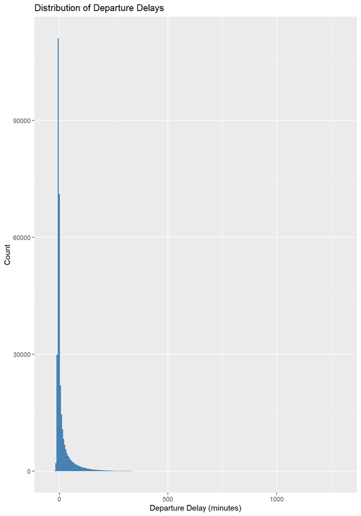

```r
# Step 5- Visualize the distributions of key variables

# Departure Delay Distribution
ggplot(flights_weather, aes(dep_delay)) +
  geom_histogram(binwidth = 5, fill = "steelblue") +
  labs(title = "Distribution of Departure Delays",
       x = "Departure Delay (minutes)",
       y = "Count")
```

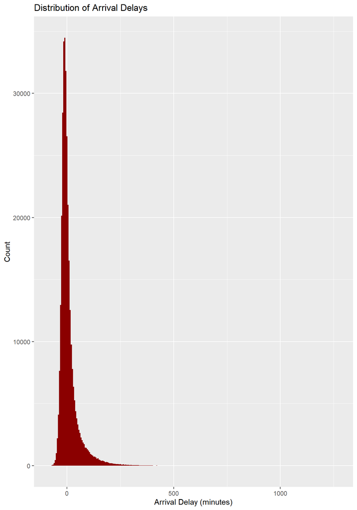

```r
# Arrival Delay Distribution
ggplot(flights_weather, aes(arr_delay)) +
  geom_histogram(binwidth = 5, fill = "darkred") +
  labs(title = "Distribution of Arrival Delays",
       x = "Arrival Delay (minutes)",
       y = "Count")
```

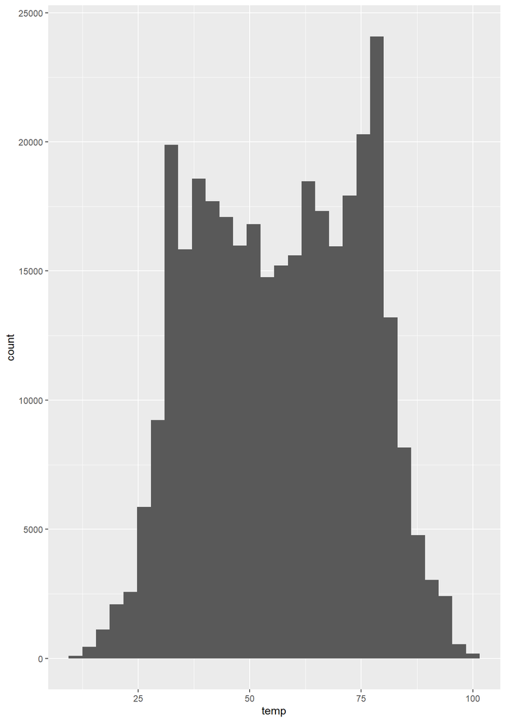

```r
# Weather Distribution
ggplot(flights_weather, aes(temp)) + geom_histogram()
```

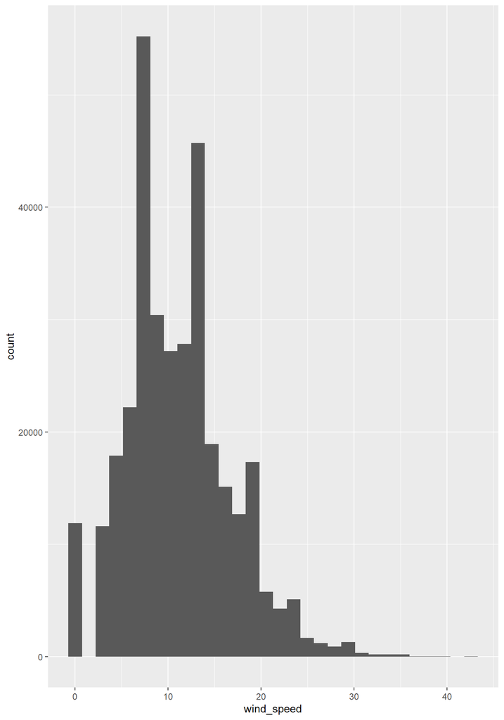

```r
ggplot(flights_weather, aes(wind_speed)) + geom_histogram()
```

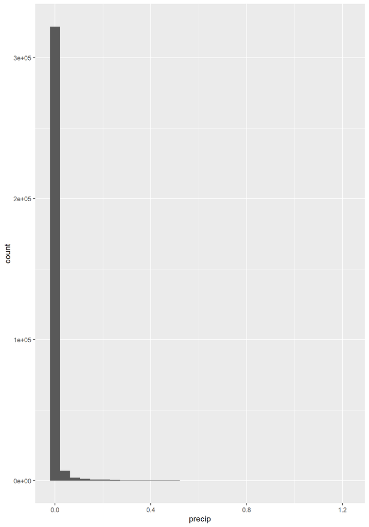

```r
ggplot(flights_weather, aes(precip)) + geom_histogram()
```

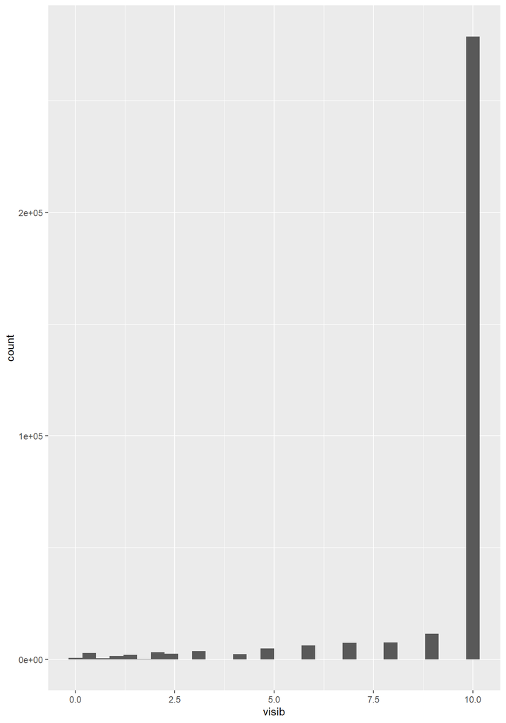

```r
ggplot(flights_weather, aes(visib)) + geom_histogram()
```

## Question 7

Calculate the average departure delay for each day (Hint: think about which variables you need in order to do this!). Which day had the worst average length of delay for departures? Now calculate the averages by day and origin. Which airport had the worst single day for delays and when was it? Now calculate the averages by hour and origin. Which airport had the worst single hour for delays (and when was it)?

# Summary

[output not shown]

```r
# Average departure delay for each day
daily_dep <- flights_weather %>%
  group_by(month, day) %>%
  summarise(avg_dep_delay = mean(dep_delay, na.rm = TRUE)) %>%
  arrange(desc(avg_dep_delay))
```

[output not shown]

```r
daily_dep
```

```
# A tibble: 365 × 3
# Groups:   month [12]
   month   day avg_dep_delay
   <int> <int>         <dbl>
 1     3     8          83.5
 2     7     1          56.2
 3     9     2          53.0
 4     7    10          52.9
 5    12     5          52.3
 6     5    23          51.1
 7     9    12          50.0
 8     6    28          48.8
 9     6    24          47.2
10     7    22          46.7
# ℹ 355 more rows
```

```r
# Average departure delay by day and origin
day_origin_dep <- flights_weather %>%
  group_by(origin, month, day) %>%
  summarise(avg_dep_delay = mean(dep_delay, na.rm = TRUE)) %>%
  arrange(desc(avg_dep_delay))
```

[output not shown]

```r
day_origin_dep
```

```
# A tibble: 1,095 × 4
# Groups:   origin, month [36]
   origin month   day avg_dep_delay
   <chr>  <int> <int>         <dbl>
 1 LGA        3     8         106.
 2 EWR        3     8          97.8
 3 LGA        9     2          80.5
 4 LGA       12     5          75.2
 5 JFK        7    10          63.6
 6 LGA        7     1          62.4
 7 EWR       12     5          61.2
 8 JFK        7     1          59.6
 9 EWR        9    12          58.7
10 EWR        5    23          58.2
# ℹ 1,085 more rows
```

```r
# Average departure delay by hour and origin
hour_origin_dep <- flights_weather %>%
  group_by(origin, month, day, hour) %>%
  summarise(avg_dep_delay = mean(dep_delay, na.rm = TRUE)) %>%
  arrange(desc(avg_dep_delay))
```

[output not shown]

```r
hour_origin_dep
```

```
# A tibble: 19,486 × 5
# Groups:   origin, month, day [1,095]
   origin month   day  hour avg_dep_delay
   <chr>  <int> <int> <dbl>         <dbl>
 1 LGA        7    28    21          280.
 2 EWR        2     9    10          269
 3 EWR        2     9     9          266
 4 LGA        9     2    16          250.
 5 LGA        7    22    18          246.
 6 LGA        7    28    19          240.
 7 JFK        4    10    21          237
 8 LGA        9    12    20          226.
 9 EWR        3     8    12          225.
10 LGA       12     5    11          221.
# ℹ 19,476 more rows
```

## Question 8

Compute the average arrival delay by destination, then add that information to the airports data frame. Make a map showing the spatial distribution of delays (you can make it however you like, but we recommend using either ggplot or leaflet). Use the color of the points to display the average delay for each airport.

# Summary

```
- I merged average arrival delay by destination into the airports dataset and created an interactive leaflet map showing the spatial distribution of delays. Each airport is plotted at its geographic location, and the color of each point represents its average arrival delay.
```

```r
# Compute average arrival delay by destination
avg_arr_delay_dest <- flights_weather %>%
  group_by(dest) %>%
  summarise(avg_arr_delay = mean(arr_delay, na.rm = TRUE))

# Add info onto the airports dataset
airports_delay <- airports %>%
  left_join(avg_arr_delay_dest, by = c("faa" = "dest"))

# Make a map of average arrival delays
library(leaflet)

# Create the same palette used for the markers
pal <- colorNumeric(
  palette = "plasma",
  domain = airports_delay$avg_arr_delay
)

leaflet(airports_delay) %>%
  addTiles() %>%
  addCircleMarkers(
    lng = ~lon,
    lat = ~lat,
    radius = 5,
    color = ~pal(avg_arr_delay),
    stroke = FALSE,
    fillOpacity = 0.8,
    popup = ~paste0(
      name, "<br>",
      "Avg Arrival Delay: ", round(avg_arr_delay, 2), " min"
    )
  ) %>%
  addLegend(
    position = "bottomright",
    pal = pal,
    values = airports_delay$avg_arr_delay,
    title = "Avg Arrival Delay (min)",
    opacity = 1
  )
```

[interactive chart not shown]

## Question 9

Create as many plots and summary statistics as needed to answer the primary question above. “Which weather phenomena have the most impact on flight delays?”

# Summary

[output not shown]

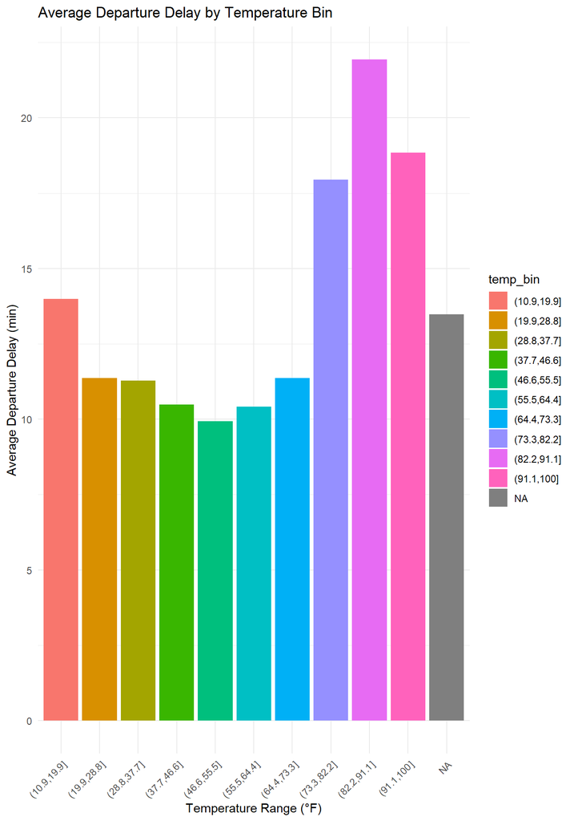

```r
# Step 1- Visualize relationships between weather and delays

## Temp vs Delays

# Summary for temp
temp_summary <- flights_weather %>%
  mutate(temp_bin = cut(temp, breaks = 10)) %>%
  group_by(temp_bin) %>%
  summarise(avg_dep_delay = mean(dep_delay, na.rm = TRUE))

# Temp Barplot
ggplot(temp_summary, aes(temp_bin, avg_dep_delay, fill = temp_bin)) +
  geom_col() +
  labs(
    title = "Average Departure Delay by Temperature Bin",
    x = "Temperature Range (°F)",
    y = "Average Departure Delay (min)"
  ) +
  theme_minimal() +
  theme(axis.text.x = element_text(angle = 45, hjust = 1))
```

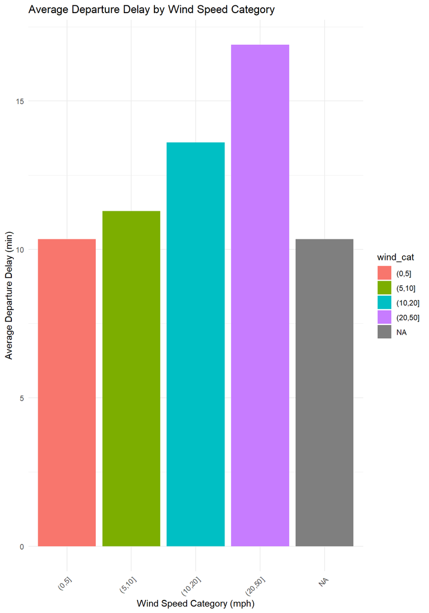

```r
## Wind Speed vs Delays

# Summary for wind speeds
wind_summary <- flights_weather %>%
  mutate(wind_cat = cut(wind_speed, breaks = c(0,5,10,20,50))) %>%
  group_by(wind_cat) %>%
  summarise(avg_dep_delay = mean(dep_delay, na.rm = TRUE))

# Wind Speed Barplot
ggplot(wind_summary, aes(wind_cat, avg_dep_delay, fill = wind_cat)) +
  geom_col() +
  labs(
    title = "Average Departure Delay by Wind Speed Category",
    x = "Wind Speed Category (mph)",
    y = "Average Departure Delay (min)"
  ) +
  theme_minimal() +
  theme(axis.text.x = element_text(angle = 45, hjust = 1))
```

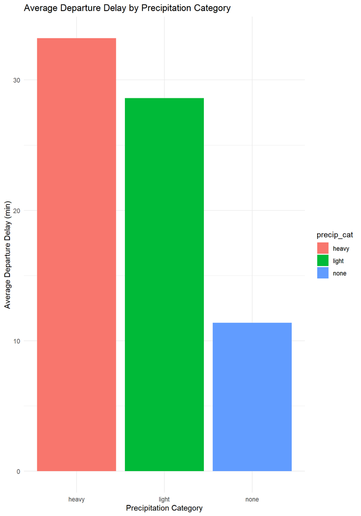

```r
## Precipitation vs Delays

# Summary for Precip
precip_summary <- flights_weather %>%
  mutate(precip_cat = case_when(
    precip == 0 ~ "none",
    precip < 0.1 ~ "light",
    TRUE ~ "heavy"
  )) %>%
  group_by(precip_cat) %>%
  summarise(avg_dep_delay = mean(dep_delay, na.rm = TRUE))

# Percip Barplot
ggplot(precip_summary, aes(precip_cat, avg_dep_delay, fill = precip_cat)) +
  geom_col() +
  labs(
    title = "Average Departure Delay by Precipitation Category",
    x = "Precipitation Category",
    y = "Average Departure Delay (min)"
  ) +
  theme_minimal()
```

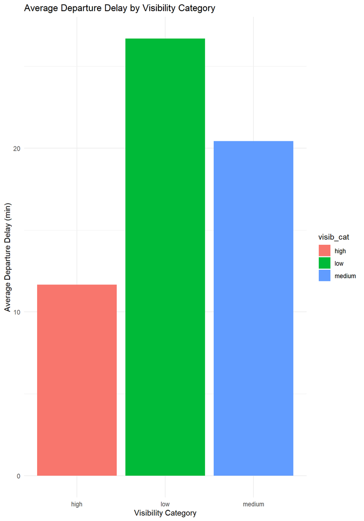

```r
## Visibility vs Delays

# Summary for Visibility
visib_summary <- flights_weather %>%
  mutate(visib_cat = case_when(
    visib < 3 ~ "low",
    visib < 7 ~ "medium",
    TRUE ~ "high"
  )) %>%
  group_by(visib_cat) %>%
  summarise(avg_dep_delay = mean(dep_delay, na.rm = TRUE))

# Visbility Barplot
ggplot(visib_summary, aes(visib_cat, avg_dep_delay, fill = visib_cat)) +
  geom_col() +
  labs(
    title = "Average Departure Delay by Visibility Category",
    x = "Visibility Category",
    y = "Average Departure Delay (min)"
  ) +
  theme_minimal()
```

```r
# Step 2- Compute correlations
corr_df <- flights_weather %>%
  select(dep_delay, arr_delay, temp, wind_speed, precip, visib) %>%
  na.omit()

cor(corr_df)
```

```
             dep_delay   arr_delay         temp  wind_speed       precip
dep_delay   1.00000000  0.91482719  0.060881644  0.04722227  0.090009700
arr_delay   0.91482719  1.00000000  0.033036731  0.06405838  0.111149370
temp        0.06088164  0.03303673  1.000000000 -0.14179075  0.009353492
wind_speed  0.04722227  0.06405838 -0.141790750  1.00000000  0.032938360
precip      0.09000970  0.11114937  0.009353492  0.03293836  1.000000000
visib      -0.09346906 -0.13559393  0.090744056  0.07174473 -0.320366819
                 visib
dep_delay  -0.09346906
arr_delay  -0.13559393
temp        0.09074406
wind_speed  0.07174473
precip     -0.32036682
visib       1.00000000
```

```r
# Step 3- Summaries by weather category

# Group precipitation
flights_weather %>%
  mutate(precip_cat = case_when(
    precip == 0 ~ "none",
    precip < 0.1 ~ "light",
    TRUE ~ "heavy"
  )) %>%
  group_by(precip_cat) %>%
  summarise(avg_dep_delay = mean(dep_delay, na.rm = TRUE))
```

```
# A tibble: 3 × 2
  precip_cat avg_dep_delay
  <chr>              <dbl>
1 heavy               33.2
2 light               28.6
3 none                11.4
```

```r
# Group visibility
flights_weather %>%
  mutate(visib_cat = case_when(
    visib < 3 ~ "low",
    visib < 7 ~ "medium",
    TRUE ~ "high"
  )) %>%
  group_by(visib_cat) %>%
  summarise(avg_dep_delay = mean(dep_delay, na.rm = TRUE))
```

```
# A tibble: 3 × 2
  visib_cat avg_dep_delay
  <chr>             <dbl>
1 high               11.7
2 low                26.7
3 medium             20.4
```

```r
# Group wind speeds
flights_weather %>%
  mutate(wind_cat = cut(wind_speed, breaks = c(0,5,10,20,50))) %>%
  group_by(wind_cat) %>%
  summarise(avg_dep_delay = mean(dep_delay, na.rm = TRUE))
```

```
# A tibble: 5 × 2
  wind_cat avg_dep_delay
  <fct>            <dbl>
1 (0,5]             10.3
2 (5,10]            11.3
3 (10,20]           13.6
4 (20,50]           16.9
5 <NA>              10.3
```